# 40-final

Fonts dels datasets: dataset 1 :

- Llibre blanc del videojoc a Catalunya
- Informes del Barcelona game / catalan game hub
- ICEC(Institut Català de les Empreses Culturals)
- ACCIÓ(Generalitat de Catalunya)
- DEV (Associació Espanyola de Videojocs)

dataset 2:

- NPD Group (EUA)
- GSD/ISFE(Europa)
- VGChart(Global)
- Steam (ingressos per genere)
- Sony/Nintendo/Microsoft

```python
# Imports
import pandas as pd
import numpy as np
import plotly.express as px
import matplotlib.pyplot as plt
import seaborn as sns
import streamlit as st
import plotly.graph_objects as go
from plotly.subplots import make_subplots
from sklearn.model_selection import train_test_split
from sklearn.linear_model import LinearRegression
from sklearn.metrics import r2_score, mean_squared_error
import plotly.io as pio
pio.templates.default = "seaborn"
```

CARREGA DE DADES:

```python
df = pd.read_csv('./dat/input/videojocs_catalunya_2016_2024.csv')
df2 = pd.read_csv('./dat/input/video_game_sales_by_genre_2016_2024.csv')
```

El primer dataset detalla la facturació, els treballadors, el estudis actius, els vieojocs produits el percentatge d'exportacio i la inversió captada acumulada. El segon dataset conté les ventes (globals, EUA) i Europa) i el tant percent global per genere i any.

ANALISI EXPLORATORIA:

```python
df
```

|  | Any | Facturacio_MEUR | Treballadors | Estudis_Actius | Videojocs_Produits | Percentatge_Exportacio | Inversio_Captada_Acumulada_MEUR |
| --- | --- | --- | --- | --- | --- | --- | --- |
| 0 | 2016 | 365 | 2500 | 120 | 70 | 55 | 5 |
| 1 | 2017 | 395 | 2700 | 130 | 75 | 58 | 10 |
| 2 | 2018 | 420 | 3000 | 135 | 80 | 60 | 18 |
| 3 | 2019 | 470 | 3200 | 140 | 85 | 65 | 25 |
| 4 | 2020 | 510 | 3600 | 160 | 90 | 68 | 45 |
| 5 | 2021 | 585 | 4000 | 180 | 100 | 70 | 65 |
| 6 | 2022 | 650 | 4300 | 200 | 115 | 72 | 90 |
| 7 | 2023 | 720 | 4700 | 230 | 130 | 73 | 115 |
| 8 | 2024 | 764 | 5000 | 262 | 145 | 74 | 130 |

```python
df["Pujada_Inversio_Absoluta"] = df["Inversio_Captada_Acumulada_MEUR"].diff().fillna(0)
df["Pujada_Inversio_Absoluta"] = df["Pujada_Inversio_Absoluta"].round(2)
```

```python
# Cambiem index a any
df = df.set_index("Any")
df
```

| Any | Facturacio_MEUR | Treballadors | Estudis_Actius | Videojocs_Produits | Percentatge_Exportacio | Inversio_Captada_Acumulada_MEUR | Pujada_Inversio_Absoluta |
| --- | --- | --- | --- | --- | --- | --- | --- |
| 2016 | 365 | 2500 | 120 | 70 | 55 | 5 | 0.0 |
| 2017 | 395 | 2700 | 130 | 75 | 58 | 10 | 5.0 |
| 2018 | 420 | 3000 | 135 | 80 | 60 | 18 | 8.0 |
| 2019 | 470 | 3200 | 140 | 85 | 65 | 25 | 7.0 |
| 2020 | 510 | 3600 | 160 | 90 | 68 | 45 | 20.0 |
| 2021 | 585 | 4000 | 180 | 100 | 70 | 65 | 20.0 |
| 2022 | 650 | 4300 | 200 | 115 | 72 | 90 | 25.0 |
| 2023 | 720 | 4700 | 230 | 130 | 73 | 115 | 25.0 |
| 2024 | 764 | 5000 | 262 | 145 | 74 | 130 | 15.0 |

```python
df.info()
```

```
<class 'pandas.core.frame.DataFrame'>
Index: 9 entries, 2016 to 2024
Data columns (total 7 columns):
 #   Column                           Non-Null Count  Dtype
---  ------                           --------------  -----
 0   Facturacio_MEUR                  9 non-null      int64
 1   Treballadors                     9 non-null      int64
 2   Estudis_Actius                   9 non-null      int64
 3   Videojocs_Produits               9 non-null      int64
 4   Percentatge_Exportacio           9 non-null      int64
 5   Inversio_Captada_Acumulada_MEUR  9 non-null      int64
 6   Pujada_Inversio_Absoluta         9 non-null      float64
dtypes: float64(1), int64(6)
memory usage: 576.0 bytes
```

```python
df.describe()
```

|  | Facturacio_MEUR | Treballadors | Estudis_Actius | Videojocs_Produits | Percentatge_Exportacio | Inversio_Captada_Acumulada_MEUR | Pujada_Inversio_Absoluta |
| --- | --- | --- | --- | --- | --- | --- | --- |
| count | 9.000000 | 9.000000 | 9.000000 | 9.000000 | 9.000000 | 9.000000 | 9.000000 |
| mean | 542.111111 | 3666.666667 | 173.000000 | 98.888889 | 66.111111 | 55.888889 | 13.888889 |
| std | 145.133942 | 888.819442 | 49.127385 | 25.954019 | 6.990072 | 46.686305 | 9.198430 |
| min | 365.000000 | 2500.000000 | 120.000000 | 70.000000 | 55.000000 | 5.000000 | 0.000000 |
| 25% | 420.000000 | 3000.000000 | 135.000000 | 80.000000 | 60.000000 | 18.000000 | 7.000000 |
| 50% | 510.000000 | 3600.000000 | 160.000000 | 90.000000 | 68.000000 | 45.000000 | 15.000000 |
| 75% | 650.000000 | 4300.000000 | 200.000000 | 115.000000 | 72.000000 | 90.000000 | 20.000000 |
| max | 764.000000 | 5000.000000 | 262.000000 | 145.000000 | 74.000000 | 130.000000 | 25.000000 |

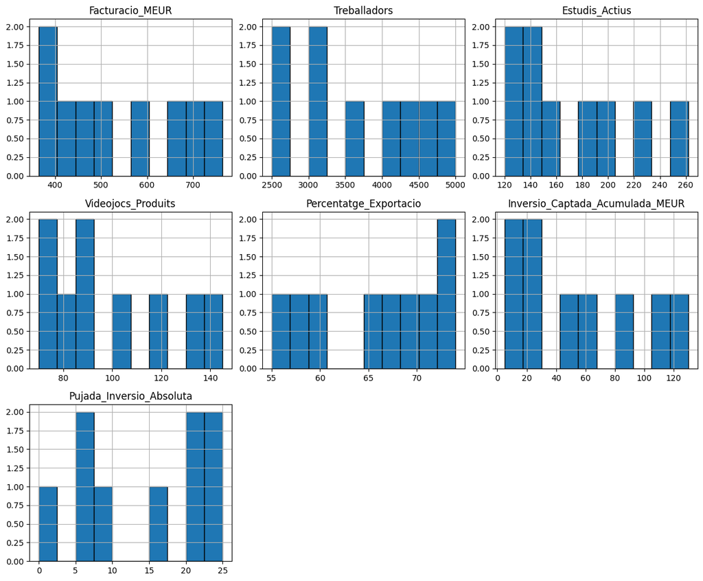

```python
numeric_cols = df.select_dtypes(include="number").columns
df[numeric_cols].hist(figsize=(12, 10), bins=10, edgecolor="black")
plt.tight_layout()
plt.show()
```

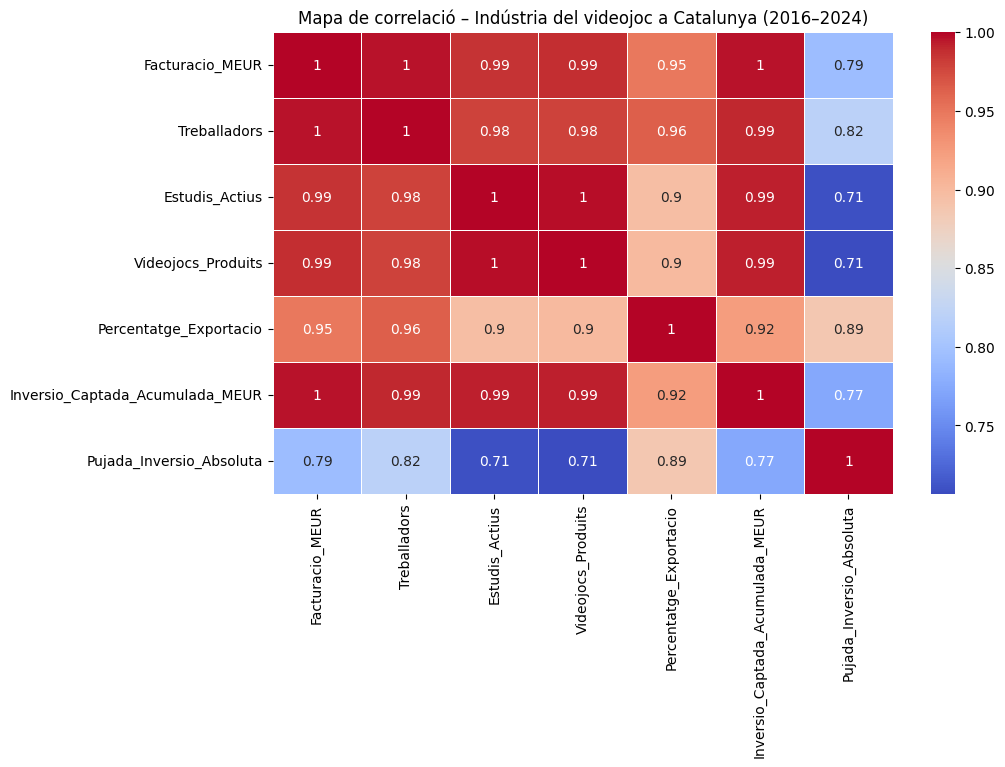

```python
%matplotlib inline


# Calcular la matriu de correlació
corr = df.corr(numeric_only=True)

# Configurar la mida del gràfic
plt.figure(figsize=(10, 6))

# Crear el mapa de calor
sns.heatmap(corr, annot=True, cmap="coolwarm", linewidths=0.5)

# Títol
plt.title("Mapa de correlació – Indústria del videojoc a Catalunya (2016–2024)")

# Mostrar el gràfic
plt.show()
```

```python
#cambiem index per la columna any:
df2 = df2.set_index("Year")
df2
```

| Year | Genre | Global_Sales | US_Sales | EU_Sales | Global_Market_Share_Percent |
| --- | --- | --- | --- | --- | --- |
| 2016 | Action | 28.49 | 12.68 | 9.21 | 30 |
| 2016 | Shooter | 19.00 | 7.79 | 5.05 | 20 |
| 2016 | Sports | 11.40 | 4.17 | 2.92 | 12 |
| 2016 | RPG | 9.50 | 4.15 | 2.95 | 10 |
| 2016 | Adventure | 7.60 | 3.20 | 1.92 | 8 |
| ... | ... | ... | ... | ... | ... |
| 2024 | Adventure | 6.86 | 2.83 | 2.15 | 8 |
| 2024 | Racing | 4.29 | 1.73 | 1.11 | 5 |
| 2024 | Fighting | 3.43 | 1.49 | 0.97 | 4 |
| 2024 | Strategy | 2.57 | 0.95 | 0.65 | 3 |
| 2024 | Simulation | 2.57 | 1.05 | 0.82 | 3 |

81 rows × 5 columns

```python
df2.info()
```

```
<class 'pandas.core.frame.DataFrame'>
Index: 81 entries, 2016 to 2024
Data columns (total 5 columns):
 #   Column                       Non-Null Count  Dtype
---  ------                       --------------  -----
 0   Genre                        81 non-null     object
 1   Global_Sales                 81 non-null     float64
 2   US_Sales                     81 non-null     float64
 3   EU_Sales                     81 non-null     float64
 4   Global_Market_Share_Percent  81 non-null     int64
dtypes: float64(3), int64(1), object(1)
memory usage: 3.8+ KB
```

```python
df2.describe()
```

|  | Global_Sales | US_Sales | EU_Sales | Global_Market_Share_Percent |
| --- | --- | --- | --- | --- |
| count | 81.000000 | 81.000000 | 81.000000 | 81.000000 |
| mean | 10.286914 | 4.098395 | 3.043580 | 10.555556 |
| std | 8.501525 | 3.406113 | 2.543213 | 8.644362 |
| min | 2.570000 | 0.930000 | 0.650000 | 3.000000 |
| 25% | 3.670000 | 1.490000 | 1.060000 | 4.000000 |
| 50% | 7.600000 | 3.040000 | 2.190000 | 8.000000 |
| 75% | 12.640000 | 5.110000 | 3.770000 | 12.000000 |
| max | 33.260000 | 13.810000 | 10.440000 | 30.000000 |

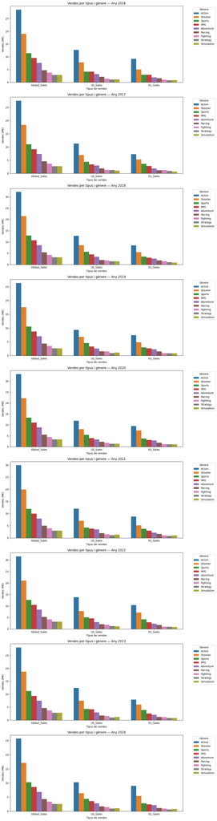

```python
# Convertir l'índex 'Year' en columna
df2 = df2.reset_index()

# Reorganitzar el dataframe a format llarg
df_long = df2.melt(
    id_vars=["Genre", "Year"],
    value_vars=["Global_Sales", "US_Sales", "EU_Sales"],
    var_name="Sales_Type",
    value_name="Sales"
)

# Llista d'anys disponibles
years = sorted(df_long["Year"].unique())

# Crear subplots
fig, axes = plt.subplots(nrows=len(years), ncols=1, figsize=(12, 5 * len(years)))

if len(years) == 1:
    axes = [axes]

for ax, year in zip(axes, years):
    data_year = df_long[df_long["Year"] == year]

    # Ordenar gèneres per vendes globals (pots canviar-ho a US_Sales o EU_Sales)
    order_genres = (
        df2[df2["Year"] == year]
        .sort_values("Global_Sales", ascending=False)["Genre"]
        .unique()
    )

    sns.barplot(
        data=data_year,
        x="Sales_Type",
        y="Sales",
        hue="Genre",
        hue_order=order_genres,
        ax=ax
    )
    ax.set_title(f"Vendes per tipus i gènere — Any {year}")
    ax.set_xlabel("Tipus de vendes")
    ax.set_ylabel("Vendes (M€)")
    ax.legend(title="Gènere", bbox_to_anchor=(1.05, 1), loc='upper left')

plt.tight_layout()
plt.show()
```

ANALISI DESCRIPTIU

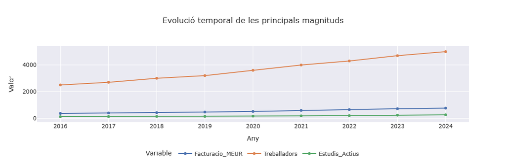

```python
df1_plot = df.reset_index()

fig3 = px.line(
    df1_plot,
    x="Any",
    y=["Facturacio_MEUR", "Treballadors", "Estudis_Actius"],
    markers=True,
    title="Evolució temporal de les principals magnituds",
    template = 'seaborn'
)

fig3.update_layout(
    xaxis_title="Any",
    yaxis_title="Valor",
    legend_title="Variable",
    legend=dict( orientation="h",
                     yanchor="bottom",
                     y=-0.5, # ajusta la distància vertical
                     xanchor="center",
                     x=0.5 )
)

fig3.show()
```

Els treballadors creixen anualment i, en menor mesura augmenten els estudis (empreses) actius del sector i la facturació, en mesura similar.

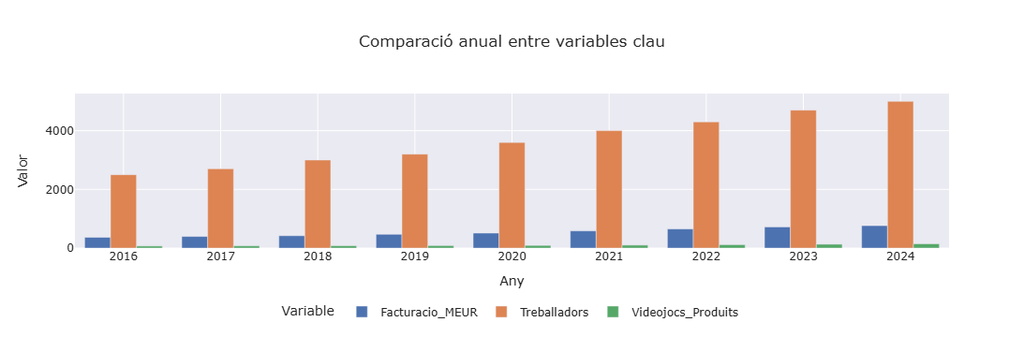

```python
fig4 = px.bar(
    df1_plot,
    x="Any",
    y=["Facturacio_MEUR", "Treballadors", "Videojocs_Produits"],
    barmode="group",
    title="Comparació anual entre variables clau"
)

fig4.update_layout(
    xaxis_title="Any",
    yaxis_title="Valor",
    legend_title="Variable",
    legend=dict( orientation="h",
                     yanchor="bottom",
                     y=-0.5, # ajusta la distància vertical
                     xanchor="center",
                     x=0.5 )
)

fig4.show()
```

Continuem veien que la tendencia es que a mes facturació, mes estudis i mes treballadors hi ha al sector i que aquesta tendencia es al alça.

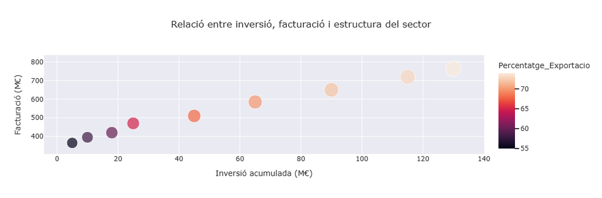

```python
fig5 = px.scatter(
    df1_plot,
    x="Inversio_Captada_Acumulada_MEUR",
    y="Facturacio_MEUR",
    size="Treballadors",
    color="Percentatge_Exportacio",
    hover_name="Any",
    title="Relació entre inversió, facturació i estructura del sector"
)

fig5.update_layout(
    xaxis_title="Inversió acumulada (M€)",
    yaxis_title="Facturació (M€)",
)

fig5.show()
```

```python
df1_plot
```

|  | Any | Facturacio_MEUR | Treballadors | Estudis_Actius | Videojocs_Produits | Percentatge_Exportacio | Inversio_Captada_Acumulada_MEUR | Pujada_Inversio_Absoluta |
| --- | --- | --- | --- | --- | --- | --- | --- | --- |
| 0 | 2016 | 365 | 2500 | 120 | 70 | 55 | 5 | 0.0 |
| 1 | 2017 | 395 | 2700 | 130 | 75 | 58 | 10 | 5.0 |
| 2 | 2018 | 420 | 3000 | 135 | 80 | 60 | 18 | 8.0 |
| 3 | 2019 | 470 | 3200 | 140 | 85 | 65 | 25 | 7.0 |
| 4 | 2020 | 510 | 3600 | 160 | 90 | 68 | 45 | 20.0 |
| 5 | 2021 | 585 | 4000 | 180 | 100 | 70 | 65 | 20.0 |
| 6 | 2022 | 650 | 4300 | 200 | 115 | 72 | 90 | 25.0 |
| 7 | 2023 | 720 | 4700 | 230 | 130 | 73 | 115 | 25.0 |
| 8 | 2024 | 764 | 5000 | 262 | 145 | 74 | 130 | 15.0 |

En aquest gràfic veiem que a mesura que la inversio acumulada i la facturació augmenten, el percentatge d'exportacions creix.

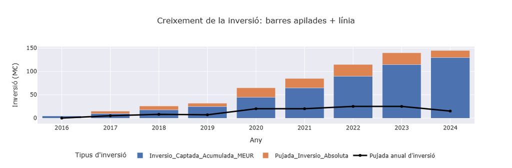

```python
# Reorganitzar a format llarg per apilar
df_long = df1_plot.melt(
    id_vars="Any",
    value_vars=["Inversio_Captada_Acumulada_MEUR", "Pujada_Inversio_Absoluta"],
    var_name="Tipus_Inversio",
    value_name="Inversio"
)

# Gràfic de barres apilades
fig8 = px.bar(
    df_long,
    x="Any",
    y="Inversio",
    color="Tipus_Inversio",
    barmode="stack",
    title="Creixement de la inversió: barres apilades + línia"
)

# Afegir línia de la inversió acumulada
fig8.add_scatter( x=df1_plot["Any"],
                  y=df1_plot["Pujada_Inversio_Absoluta"],
                  mode="lines+markers",
                  name="Pujada anual d'inversió",
                  line=dict(color="black", width=3)
                )


fig8.update_layout(
        xaxis_title="Any",
        yaxis_title="Inversió (M€)",
        legend_title="Tipus d'inversió",
        legend=dict( orientation="h",
                     yanchor="bottom",
                     y=-0.5, # ajusta la distància vertical
                     xanchor="center",
                     x=0.5 )
)

fig8.show()
```

En aquest gràfic veiem que la tendencia anual en la inversió captada en el sector fluctua, tot i que segueix pujant, amb una pujada 10 punts menor l'any 2024 respecte a l'any anterior.

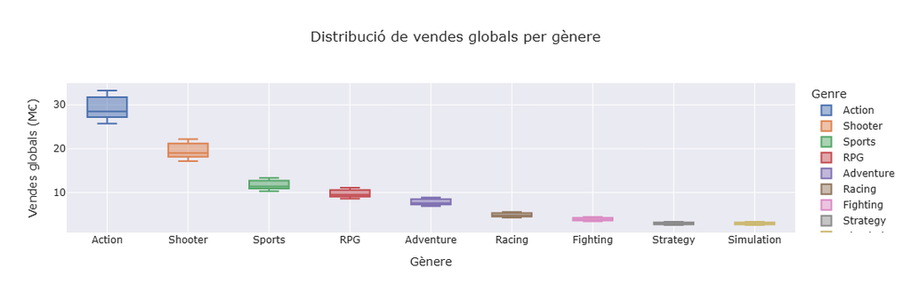

```python
fig6 = px.box(
    df2,
    x="Genre",
    y="Global_Sales",
    color="Genre",
    title="Distribució de vendes globals per gènere",
)

fig6.update_layout(xaxis_title="Gènere", yaxis_title="Vendes globals (M€)")
fig6.show()
```

Les vendes globals per gènere deixen constancia que, globalment, el gènere de videojoc més venut es el d'acció, seguit del shooter i dels videojocs d'esports.

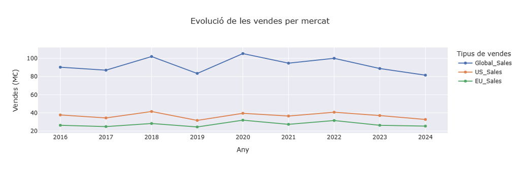

```python
# Agrupar per any i sumar vendes
df_year = df2.groupby("Year", as_index=False)[["Global_Sales", "US_Sales", "EU_Sales"]].sum()

# Reorganitzar a format llarg per poder fer múltiples línies
df_long = df_year.melt(
    id_vars="Year",
    value_vars=["Global_Sales", "US_Sales", "EU_Sales"],
    var_name="Sales_Type",
    value_name="Sales"
)

fig7 = px.line(
    df_long,
    x="Year",
    y="Sales",
    color="Sales_Type",
    markers=True,
    title="Evolució de les vendes per mercat"
)

fig7.update_layout(
    xaxis_title="Any",
    yaxis_title="Vendes (M€)",
    legend_title="Tipus de vendes"
)

fig7.show()
```

La tendencia de vendes al mercat global es lleugerament descendent en els ultims anys, tot i les pujades al 2018 i al 2020.

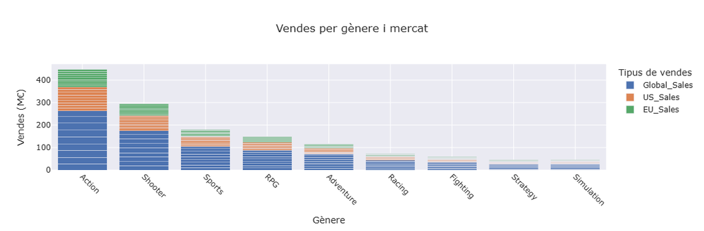

```python
# Reorganitzar a format llarg per poder apilar
df_long = df2.melt(
    id_vars=["Genre", "Year"],
    value_vars=["Global_Sales", "US_Sales", "EU_Sales"],
    var_name="Sales_Type",
    value_name="Sales"
)

fig9 = px.bar(
    df_long,
    x="Genre",
    y="Sales",
    color="Sales_Type",
    title="Vendes per gènere i mercat",
    barmode="stack"
)

fig9.update_layout(
    xaxis_title="Gènere",
    yaxis_title="Vendes (M€)",
    legend_title="Tipus de vendes",
    xaxis_tickangle=45
)

fig9.show()
```

Amb aquest gràfic queda clar que el genere per exelència en el sector dels videojocs es el d'acció, tant globalment com a Europa i als Estat Units, i que el mercat segueix els mateixos patrons sigui als Estat Units, a Europa o globalment. Aquest fet no ha cambiat en els últims 8 anys. En conclusió el gènere que pot reportar més beneficis a un estudi de videojocs es el d'acció.

ANALISI PREDICTIU:

```python
# Variables explicatives
X = df[[
    "Treballadors",
    "Estudis_Actius",
    "Videojocs_Produits",
    "Percentatge_Exportacio",
    "Inversio_Captada_Acumulada_MEUR",
    "Pujada_Inversio_Absoluta"
]]

# Variable objectiu
y = df["Facturacio_MEUR"]
```

```python
model = LinearRegression()
model.fit(X, y)
```

```
LinearRegression()
```

```python
coeficients = pd.DataFrame({
    "Variable": X.columns,
    "Coeficient": model.coef_
})

coeficients
```

|  | Variable | Coeficient |
| --- | --- | --- |
| 0 | Treballadors | 0.023493 |
| 1 | Estudis_Actius | -0.854062 |
| 2 | Videojocs_Produits | 0.523851 |
| 3 | Percentatge_Exportacio | 4.601771 |
| 4 | Inversio_Captada_Acumulada_MEUR | 2.827658 |
| 5 | Pujada_Inversio_Absoluta | -1.355929 |

```python
r2 = model.score(X, y)
r2
```

```
0.9991842916936222
```

```python
# ----------------------------- # 3. PREDICCIÓ FUTURA (2025–2030) # -----------------------------
anys_futurs = np.arange(2025, 2031)

# Suposem una projecció simple

df_futur = pd.DataFrame({ "Treballadors": np.linspace(5200, 6500, len(anys_futurs)),
                          "Estudis_Actius": np.linspace(270, 350, len(anys_futurs)),
                          "Videojocs_Produits": np.linspace(155, 200, len(anys_futurs)),
                          "Percentatge_Exportacio": np.linspace(75, 80, len(anys_futurs)),
                          "Inversio_Captada_Acumulada_MEUR": np.linspace(150, 250, len(anys_futurs)),
                          "Pujada_Inversio_Absoluta": np.linspace(20, 25, len(anys_futurs)) }, index=anys_futurs)
prediccions = model.predict(df_futur)
```

[output not shown]

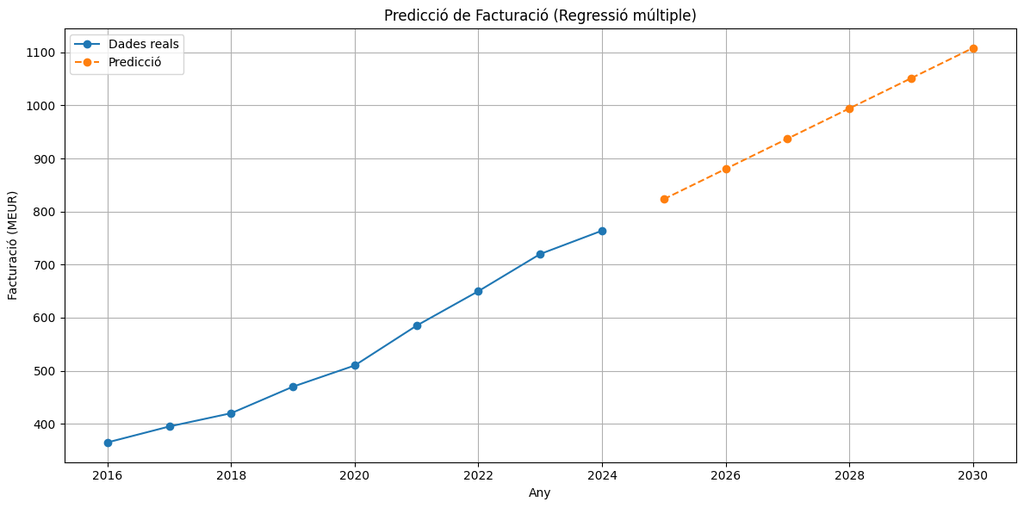

```python
# ----------------------------- # 4. GRÀFIC # -----------------------------
plt.figure(figsize=(12,6))
# Dades reals
plt.plot(df.index, df["Facturacio_MEUR"], marker="o", label="Dades reals")
# Predicció
plt.plot(anys_futurs, prediccions, marker="o", linestyle="--", label="Predicció")
plt.title("Predicció de Facturació (Regressió múltiple)")
plt.xlabel("Any")
plt.ylabel("Facturació (MEUR)")
plt.grid(True)
plt.legend()
plt.tight_layout()
plt.show()
```

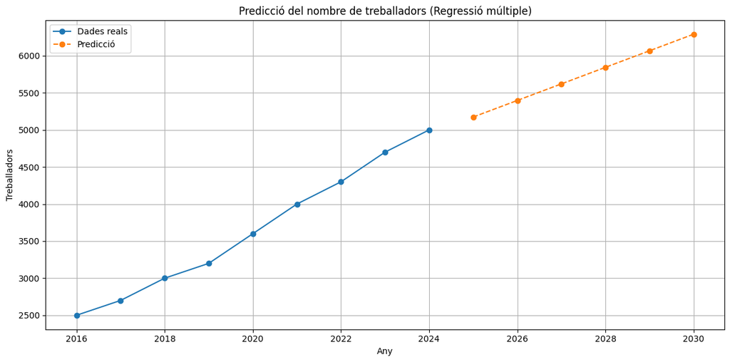

```python
# -----------------------------
# 2. MODEL DE REGRESSIÓ MÚLTIPLE
# -----------------------------
X = df.drop(columns=["Treballadors"])
y = df["Treballadors"]

model = LinearRegression()
model.fit(X, y)

# -----------------------------
# 3. PREDICCIÓ FUTURA (2025–2030)
# -----------------------------
anys_futurs = np.arange(2025, 2031)

# Projeccions simples (pots ajustar-les segons el teu criteri)
df_futur = pd.DataFrame({
    "Facturacio_MEUR": np.linspace(800, 1000, len(anys_futurs)),
    "Estudis_Actius": np.linspace(270, 350, len(anys_futurs)),
    "Videojocs_Produits": np.linspace(155, 200, len(anys_futurs)),
    "Percentatge_Exportacio": np.linspace(75, 80, len(anys_futurs)),
    "Inversio_Captada_Acumulada_MEUR": np.linspace(150, 250, len(anys_futurs)),
    "Pujada_Inversio_Absoluta": np.linspace(20, 25, len(anys_futurs))
}, index=anys_futurs)

prediccions = model.predict(df_futur)

# -----------------------------
# 4. GRÀFIC
# -----------------------------
plt.figure(figsize=(12,6))

# Dades reals
plt.plot(df.index, df["Treballadors"], marker="o", label="Dades reals")

# Predicció
plt.plot(anys_futurs, prediccions, marker="o", linestyle="--", label="Predicció")

plt.title("Predicció del nombre de treballadors (Regressió múltiple)")
plt.xlabel("Any")
plt.ylabel("Treballadors")
plt.grid(True)
plt.legend()
plt.tight_layout()
plt.show()
```

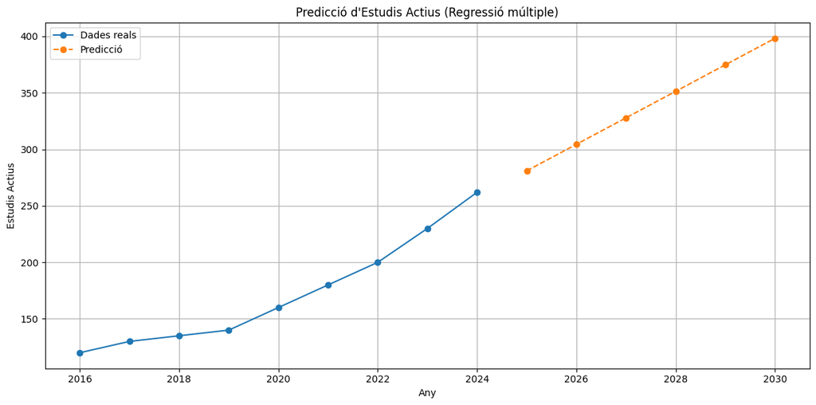

```python
# -----------------------------
# MODEL
# -----------------------------
X = df.drop(columns=["Estudis_Actius"])
y = df["Estudis_Actius"]

model = LinearRegression()
model.fit(X, y)

# -----------------------------
# PREDICCIÓ FUTURA
# -----------------------------
anys_futurs = np.arange(2025, 2031)

df_futur2 = pd.DataFrame({
    "Facturacio_MEUR": np.linspace(800, 1000, len(anys_futurs)),
    "Treballadors": np.linspace(5200, 6500, len(anys_futurs)),
    "Videojocs_Produits": np.linspace(155, 200, len(anys_futurs)),
    "Percentatge_Exportacio": np.linspace(75, 80, len(anys_futurs)),
    "Inversio_Captada_Acumulada_MEUR": np.linspace(150, 250, len(anys_futurs)),
    "Pujada_Inversio_Absoluta": np.linspace(20, 25, len(anys_futurs))
}, index=anys_futurs)

pred_estudis = model.predict(df_futur2)

# -----------------------------
# GRÀFIC
# -----------------------------
plt.figure(figsize=(12,6))
plt.plot(df.index, df["Estudis_Actius"], marker="o", label="Dades reals")
plt.plot(anys_futurs, pred_estudis, marker="o", linestyle="--", label="Predicció")
plt.title("Predicció d'Estudis Actius (Regressió múltiple)")
plt.xlabel("Any")
plt.ylabel("Estudis Actius")
plt.grid(True)
plt.legend()
plt.tight_layout()
plt.show()
```

```python
df
```

| Any | Facturacio_MEUR | Treballadors | Estudis_Actius | Videojocs_Produits | Percentatge_Exportacio | Inversio_Captada_Acumulada_MEUR | Pujada_Inversio_Absoluta |
| --- | --- | --- | --- | --- | --- | --- | --- |
| 2016 | 365 | 2500 | 120 | 70 | 55 | 5 | 0.0 |
| 2017 | 395 | 2700 | 130 | 75 | 58 | 10 | 5.0 |
| 2018 | 420 | 3000 | 135 | 80 | 60 | 18 | 8.0 |
| 2019 | 470 | 3200 | 140 | 85 | 65 | 25 | 7.0 |
| 2020 | 510 | 3600 | 160 | 90 | 68 | 45 | 20.0 |
| 2021 | 585 | 4000 | 180 | 100 | 70 | 65 | 20.0 |
| 2022 | 650 | 4300 | 200 | 115 | 72 | 90 | 25.0 |
| 2023 | 720 | 4700 | 230 | 130 | 73 | 115 | 25.0 |
| 2024 | 764 | 5000 | 262 | 145 | 74 | 130 | 15.0 |

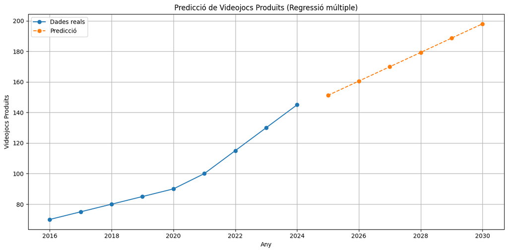

```python
# -----------------------------
# MODEL
# -----------------------------
X = df.drop(columns=["Videojocs_Produits"])
y = df["Videojocs_Produits"]

model = LinearRegression()
model.fit(X, y)

# -----------------------------
# PREDICCIÓ FUTURA
# -----------------------------

anys_futurs = np.arange(2025, 2031)

df_futur3 = pd.DataFrame({
    "Facturacio_MEUR": np.linspace(800, 1000, len(anys_futurs)),
    "Treballadors": np.linspace(5200, 6500, len(anys_futurs)),
    "Estudis_Actius": np.linspace(270, 350, len(anys_futurs)),
    "Percentatge_Exportacio": np.linspace(75, 80, len(anys_futurs)),
    "Inversio_Captada_Acumulada_MEUR": np.linspace(150, 250, len(anys_futurs)),
    "Pujada_Inversio_Absoluta": np.linspace(20, 25, len(anys_futurs))
}, index=anys_futurs)

pred_videojocs = model.predict(df_futur3)

# -----------------------------
# GRÀFIC
# -----------------------------
plt.figure(figsize=(12,6))
plt.plot(df.index, df["Videojocs_Produits"], marker="o", label="Dades reals")
plt.plot(anys_futurs, pred_videojocs, marker="o", linestyle="--", label="Predicció")
plt.title("Predicció de Videojocs Produïts (Regressió múltiple)")
plt.xlabel("Any")
plt.ylabel("Videojocs Produïts")
plt.grid(True)
plt.legend()
plt.tight_layout()
plt.show()
```

CONCLUSIONS:

Després de realitzar l'estudi de les dades dels últims anys i veient els resultats dels analisis descriptiu i predictiu, podem arrribar a les següents conclusions: